# David-Grijalva-For-Live-Session-Unit-1

David Grijalva

8/18/2020

# For Live Session Unit 1

Here is the working R code for the live session assignment for unit 1.  
The code is split into 3 sections:  
1) Data Science Profile  
2) Central Limit Theorem  
3) T-test

### Data Science Profile

Make a bar plot for your data science profile

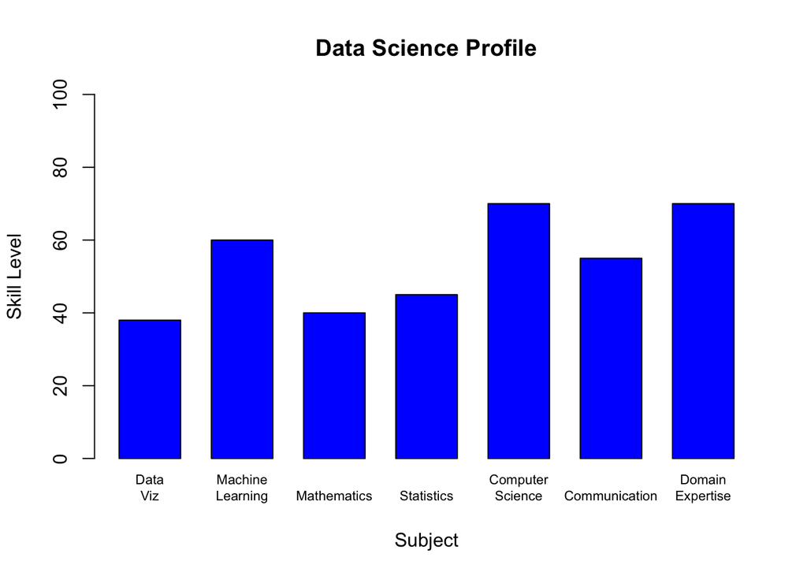

```r
# Create arrays with subjscts and skill levels
values = c(38, 60, 40, 45, 70, 55, 70)
area = c("Data\nViz", "Machine\nLearning", "Mathematics", "Statistics",
          "Computer\nScience", "Communication", "Domain\nExpertise")

dfp = data.frame(Area = area, Values = values)

# Build Barchart
barplot(dfp$Values, names.arg = dfp$Area, col="blue", ylab="Skill Level",
        xlab ="Subject", main="Data Science Profile", space=0.5, cex.names=0.70,
        ylim=c(0,100))
```

### CLT

1 - Generate a population of 10,000,000 from a chi-square distribution with 2 degrees of freedom.  
2 - Provide a histogram of this population… display the right skewness.  
3 - Record the mean and standard deviation of this population.  
4 - What should be the mean and standard error of the mean (standard deviation of the distribution of sample means)?  
5- Adapt the CLT code to draw 10,000 means each of size 50 from this population and provide the sampling distribution of this sample mean.  
6 -Provide a histogram of these 10,000 sample means  
7- What is the mean and standard deviation of these 10,000 sample means?

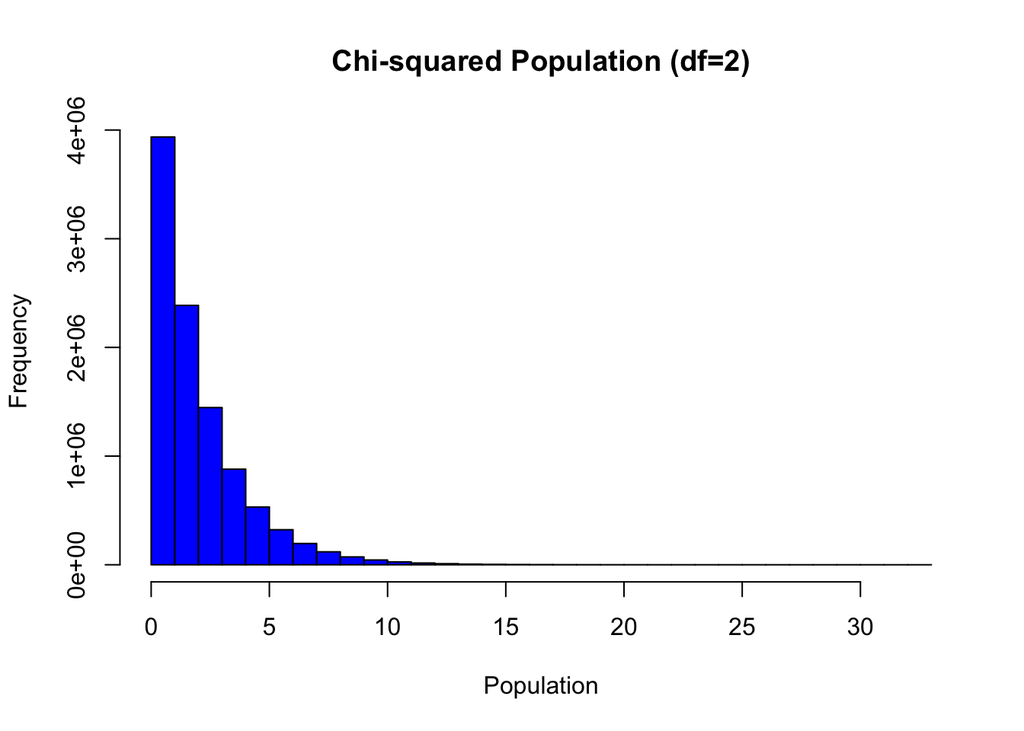

```r
# Generate chi-square population
population = rchisq(10000000, 2)
hist(population, main = "Chi-squared Population (df=2)", xlab="Population", col="blue")
```

```r
# Population Mean
mean(population)
```

```
## [1] 1.999545
```

```r
# Population Standard Deviation
sd(population)
```

```
## [1] 1.999778
```

#### What is the expected sample mean and standard deviation?

According to the CLT we expect that the sample means approximates to the one of the population and that the standard deviation, given a large enough sample will be smaller that the one from the original distribution.  
The expected mean is 2.  
The expected standard deviation is less than 2. I believe the number of samples should be large enough.

```r
#####################################################
# Funciton: xbarGenerator
# Argements: samplesize: the size of the sample that each sample mean is based on.
#            number_of_samples: the number of samples and thus sample means we will generate
# Author: David Grijalva
#####################################################
xbarGenerator = function(sampleSize = 50,number_of_samples = 10000)
{
  for(i in 1:number_of_samples)
  {
    theSample = sample(population,sampleSize)
    xbar = mean(theSample)
    xBarVec = c(xBarVec, xbar)
  }
  return(xBarVec)
}

# Run function
xBarVec = c()
xbars = xbarGenerator(50,10000)
length(xbars)
```

```
## [1] 10000
```

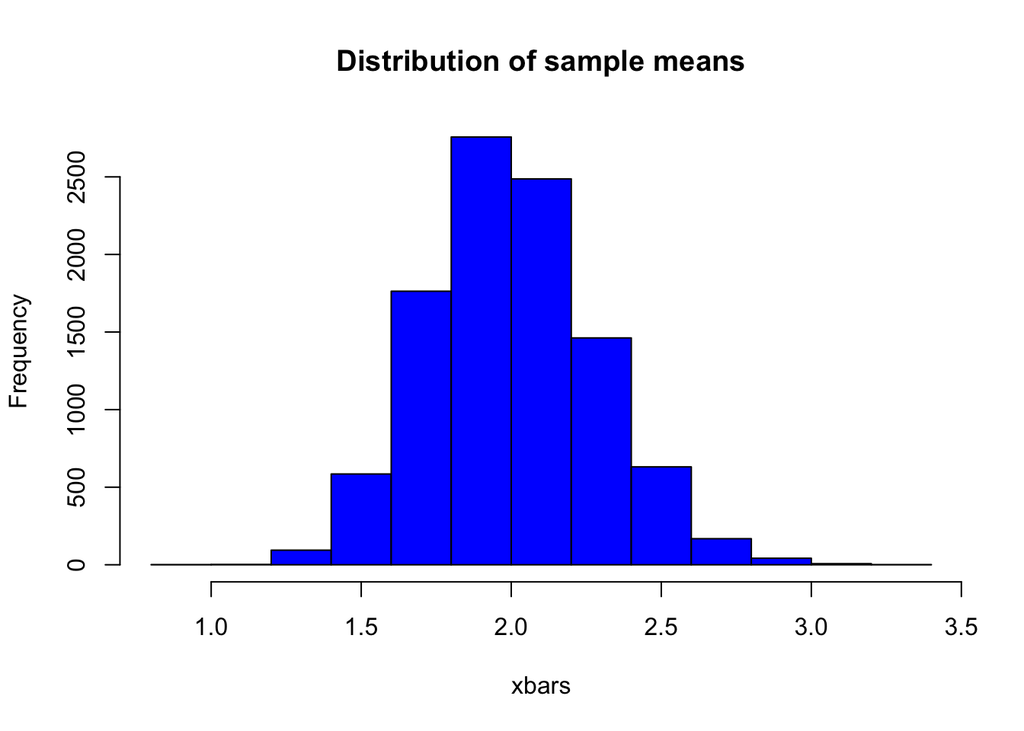

```r
hist(xbars, col="Blue", main="Distribution of sample means")
```

```r
# xbars Mean
mean(xbars)
```

```
## [1] 2.000234
```

```r
# xbars Standard Deviation
sd(xbars)
```

```
## [1] 0.2814645
```

### T-test

conduct a six step hypothesis test

Data: 25, 19, 37, 29, 40, 28, 31 Claim: The age of patrons is different than 21 years. Alpha=0.05

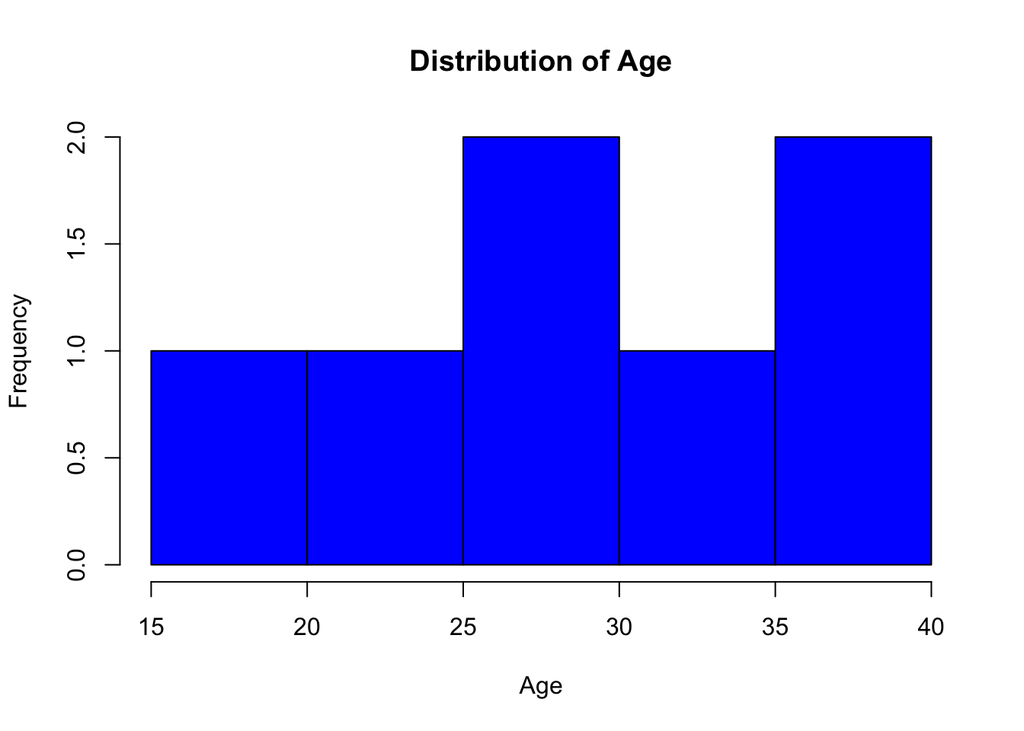

```r
# Data
ages = c(25,19,37,29,40,28,31)
hist(ages, main="Distribution of Age", col="Blue", xlab="Age")
```

```r
# Sample mean
mean(ages)
```

```
## [1] 29.85714
```

```r
# Sample standard deviation
sd(ages)
```

```
## [1] 7.081162
```

*Step 1:*  
This is a one sample two sides t-test.  
h0 = 21  
h1 != 21

*Step 2*  
df = 6  
Critical value = 2.447

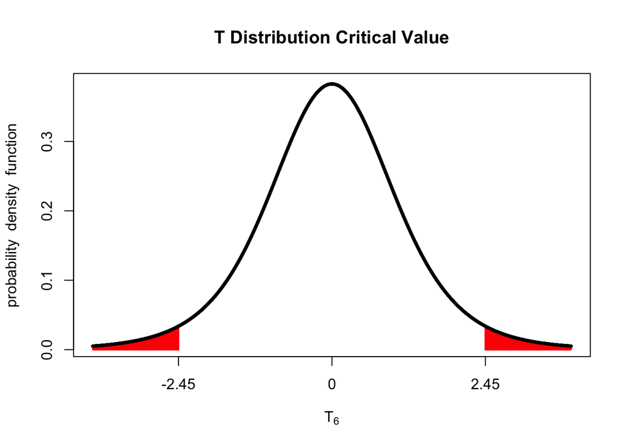

```r
library(fastGraph)

shadeDist( c(- 2.447, 2.447), "dt", 6, main = "T Distribution Critical Value" )
```

*Step 3,4*

```r
t.test(ages, mu=21, conf.level=0.95)
```

```
##
##  One Sample t-test
##
## data:  ages
## t = 3.3093, df = 6, p-value = 0.01622
## alternative hypothesis: true mean is not equal to 21
## 95 percent confidence interval:
##  23.30816 36.40613
## sample estimates:
## mean of x
##  29.85714
```

*Step 5*  
The P-value is less than 0.05, hence we reject the null hypothesis

*Step 6*  
Conclusion: There is enough evidence that suggests that the mean age of patrons is different from 21 years old (P-value: 0.01622).